# Visual Information

Information & Interaction Design

Mick McQuaid

mcq@utexas.edu

University of Texas at Austin

09 Nov 2026

# Week TWELVE

# Visual Information

## Semiology of graphics

pioneering work in data visualization

## Semiology of graphics

the name of the textbook for what I’d like to teach you today

## Semiology of graphics

how to make graphics systematically

## Semiology of graphics

you may think graphics are separate from information

## Semiology of graphics

you may think graphics should be constructed by artists

## Semiology of graphics

what about a graphics system to express information?

## Semiology of graphics

it does not belong to the artist

## Semiology of graphics

it does not belong to the artist

Salvador Dali is pictured at right

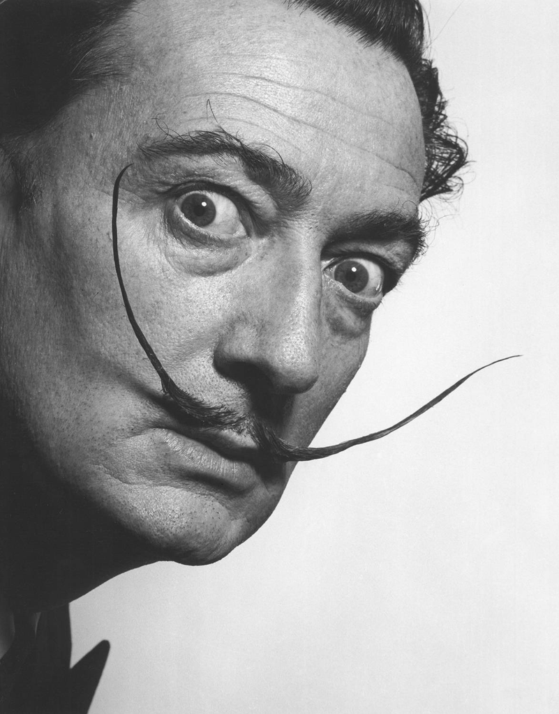

## Semiology of graphics

it belongs to anyone communicating information

## Information needs graphics

give me half an hour to convince you of this

## First an exercise

please take 5 minutes to sketch a graphic

## A table from the Census Bureau

a subset of manufacturing data

[figure not shown]

## Industry in Oregon counties

36 counties: all mfg subsectors, total sales, hours worked, wages

## How would you graphically portray some or all?

whole table available at: Canvas > Files > misc > ocounties.pdf

## Pretend you’re going to give the table & sketch to an assistant to polish

whole table available at: Canvas > Files > misc > ocounties.pdf

## While you do that I’ll show some images

I image googled statistics on Oregon counties

## While you do that I’ll show some images

I image googled statistics on Oregon counties

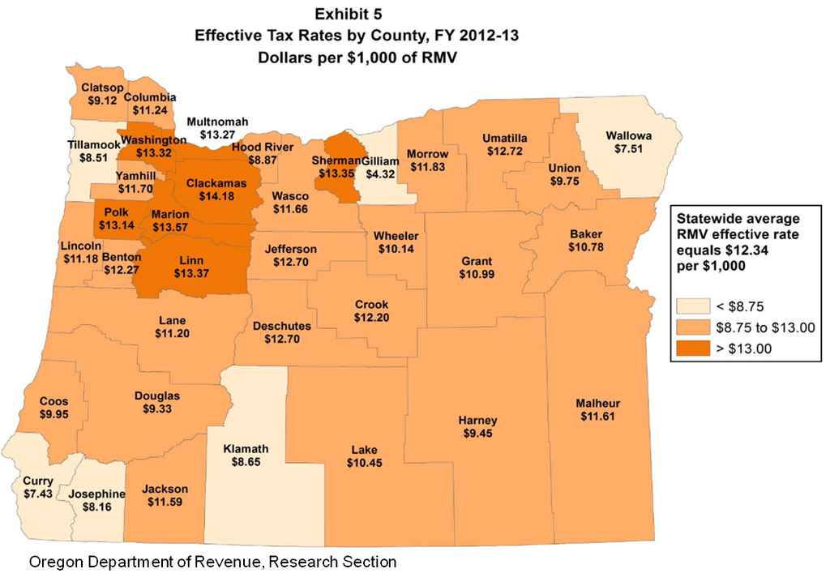

## While you do that I’ll show some images

I image googled statistics on Oregon counties

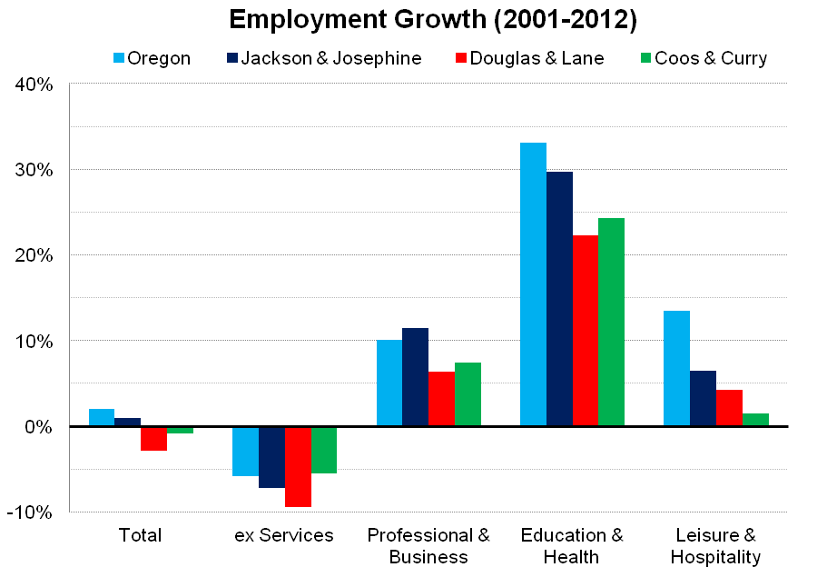

## While you do that I’ll show some images

I image googled statistics on Oregon counties

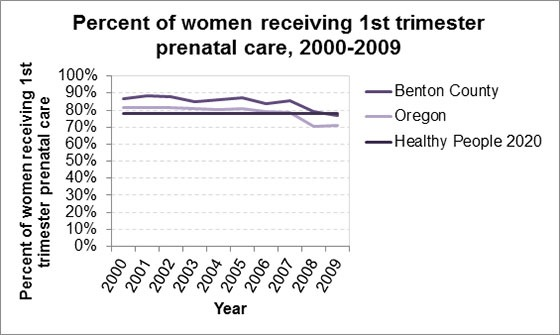

## While you do that I’ll show some images

I image googled statistics on Oregon counties

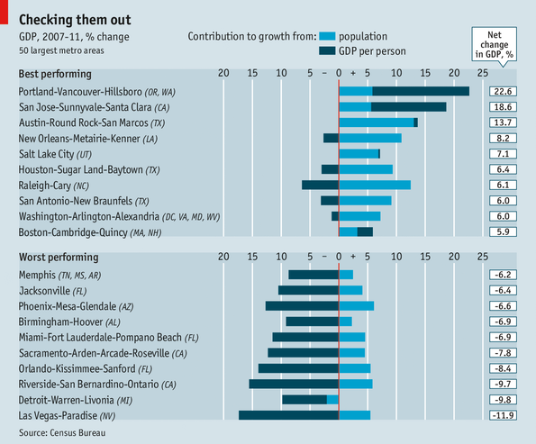

## While you do that I’ll show some images

I image googled statistics on Oregon counties

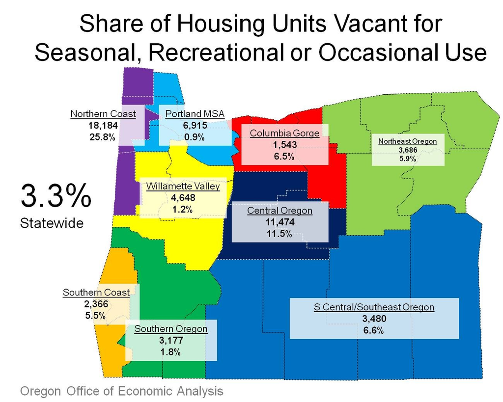

## While you do that I’ll show some images

I image googled statistics on Oregon counties

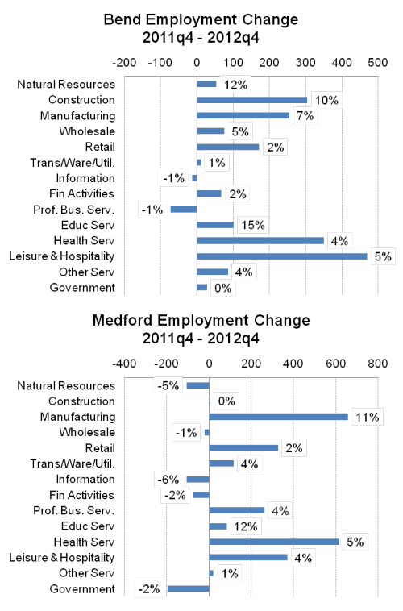

## While you do that I’ll show some images

I image googled statistics on Oregon counties

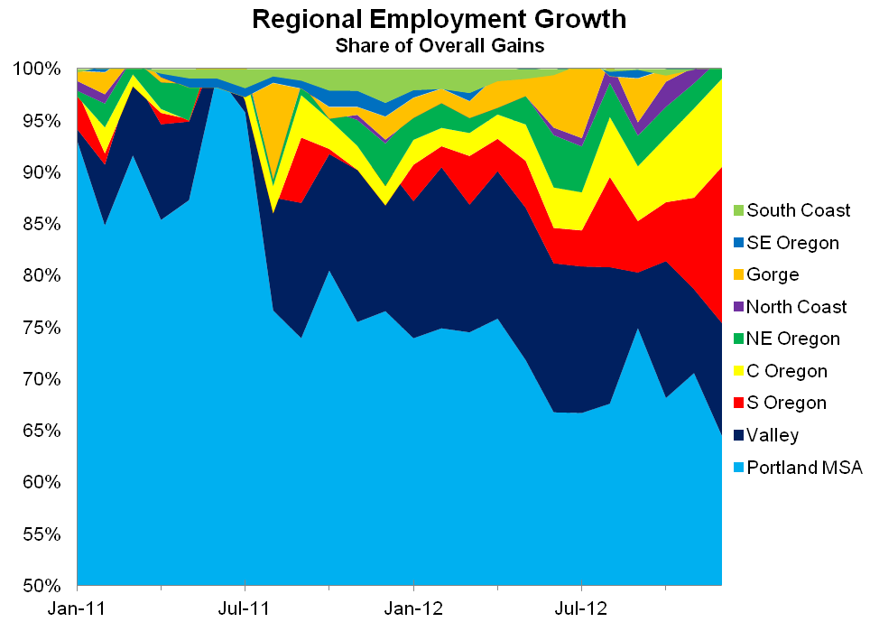

## While you do that I’ll show some images

I image googled statistics on Oregon counties

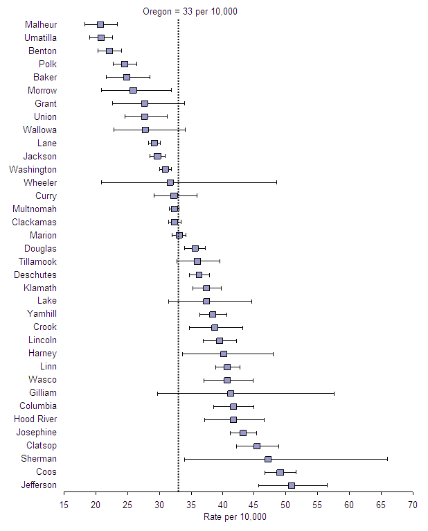

## While you do that I’ll show some images

I image googled statistics on Oregon counties

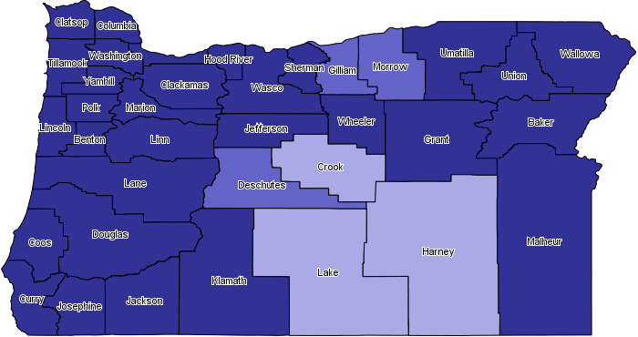

## This textbook was unknown in English-speaking countries until …

[figure not shown]

## … this very popular book made it okay for quant people to talk about graphics …

[figure not shown]

## The basic problem you just tackled

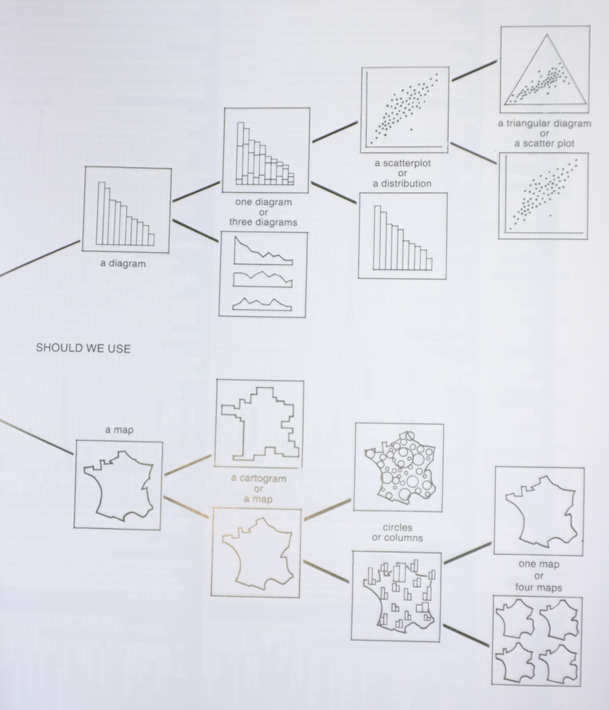

## The basic problem you just tackled

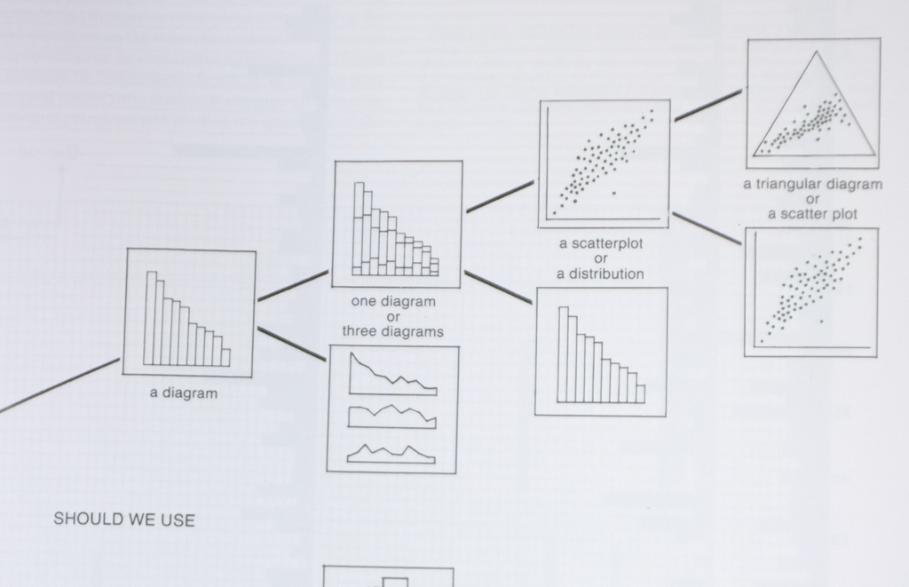

## The basic problem you just tackled

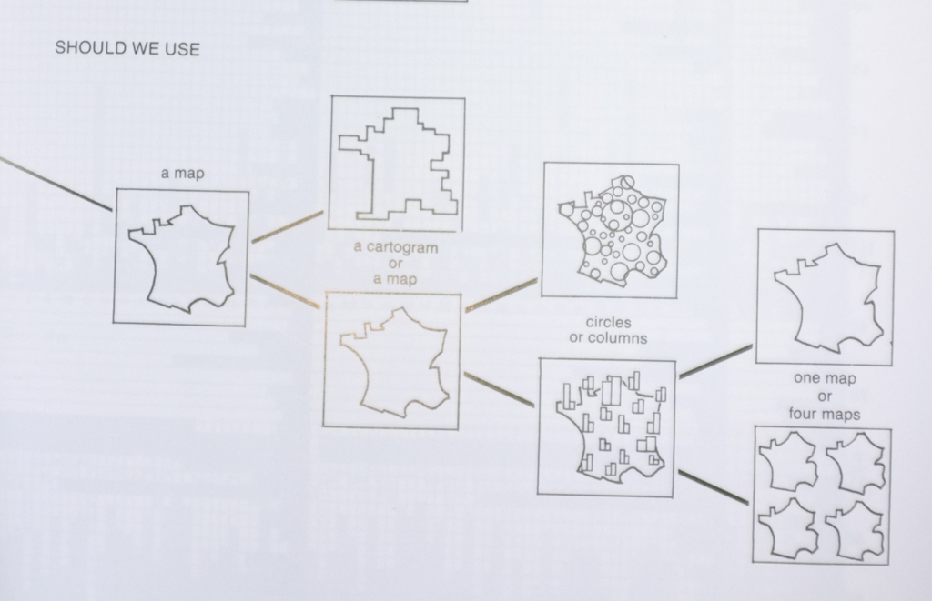

## You chose retinal variables matched to relationships

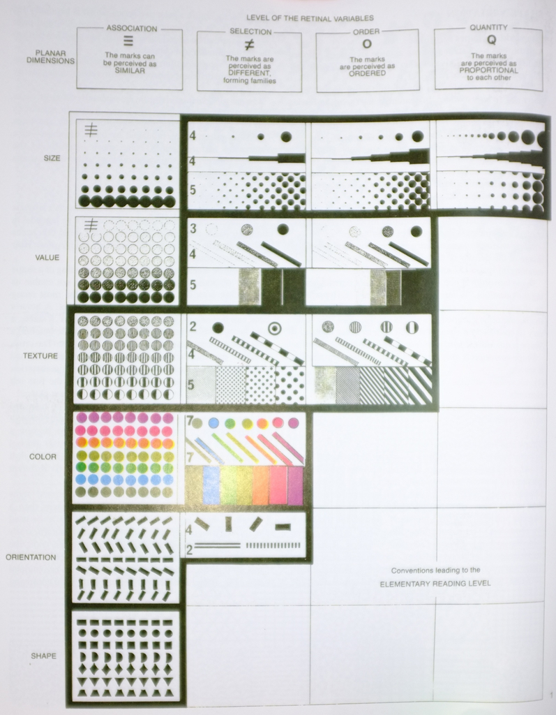

## Let’s drill down into one retinal variable, color

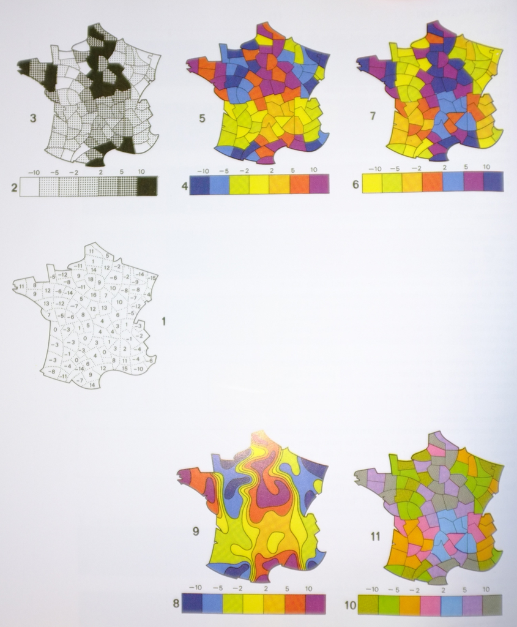

## Imagine some statistic for each county

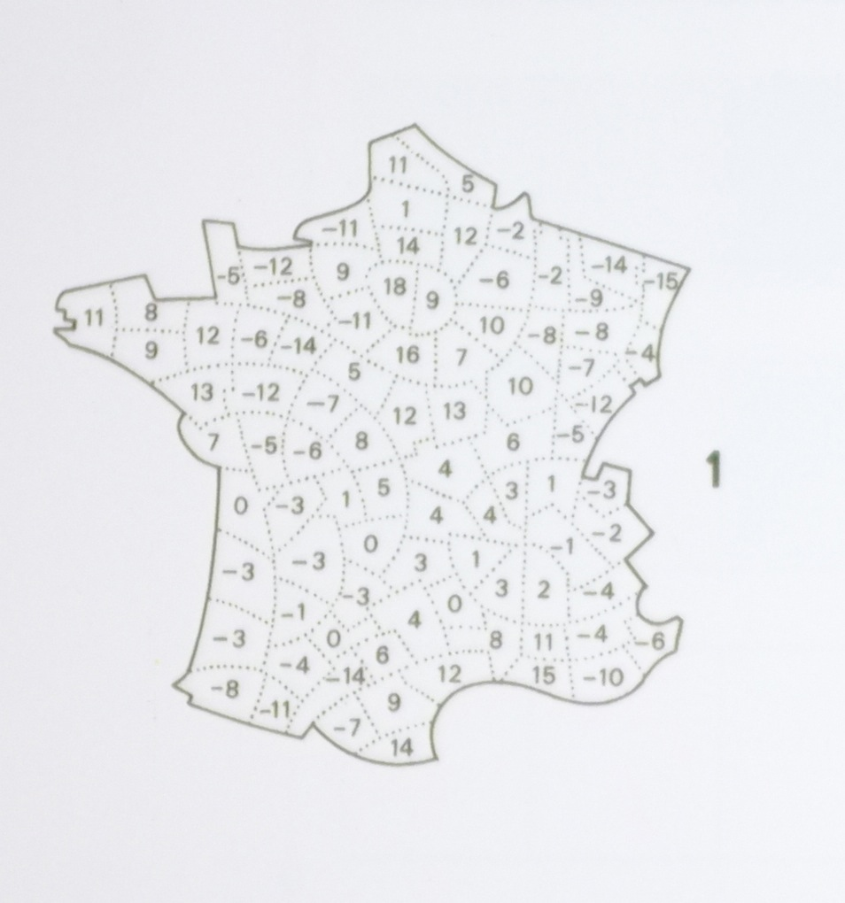

## We can easily perceive bins by value

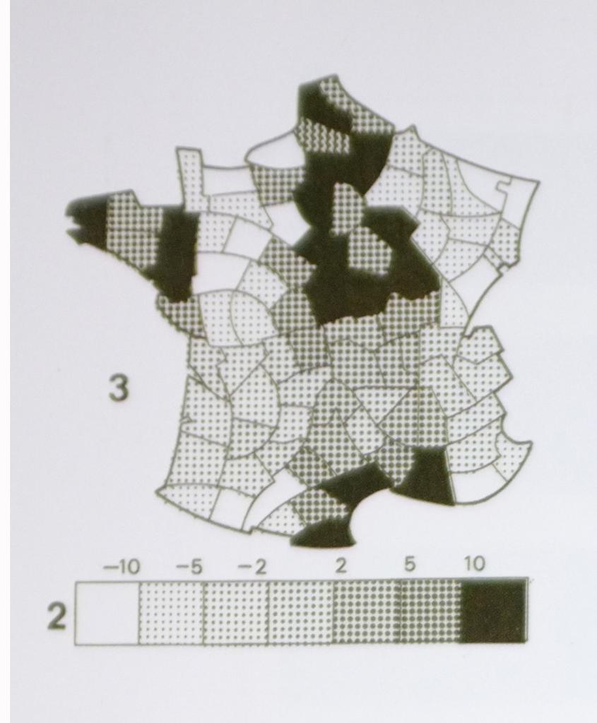

## We can try the color spectrum but what’s wrong?

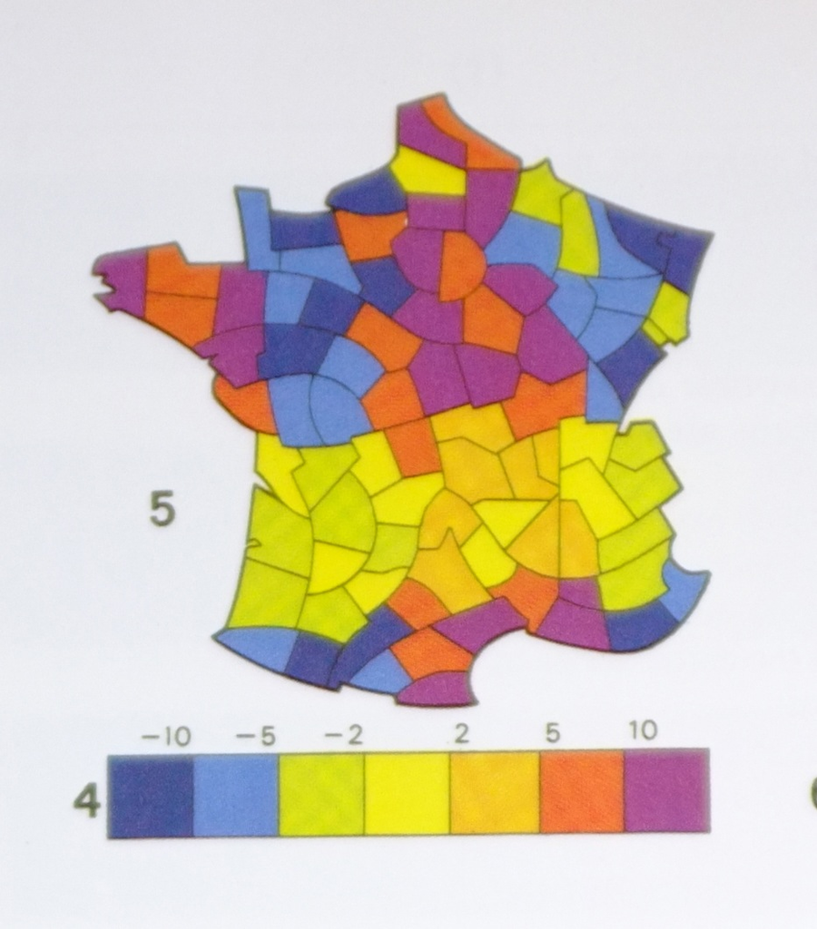

## We see the spectrum as a wheel not as a line

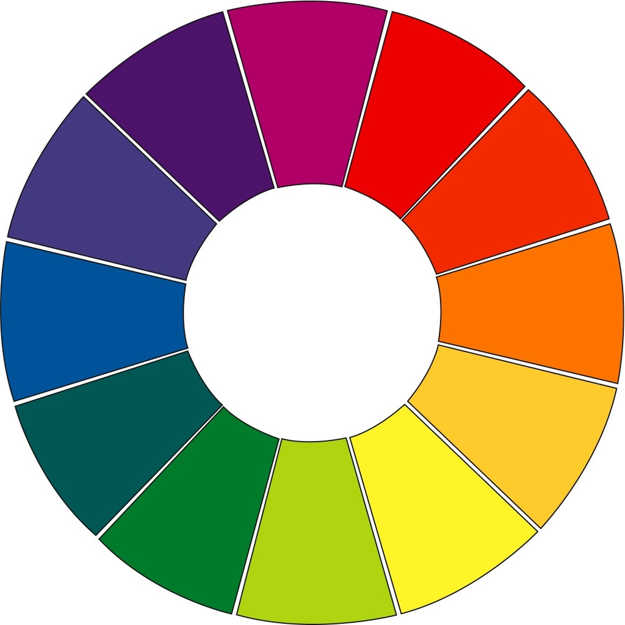

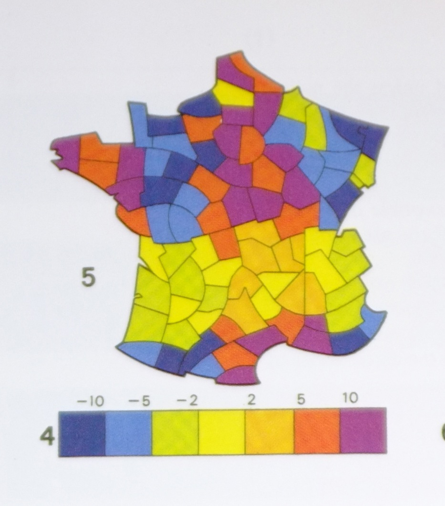

## We can do better by ‘cutting’ the wheel in a different place

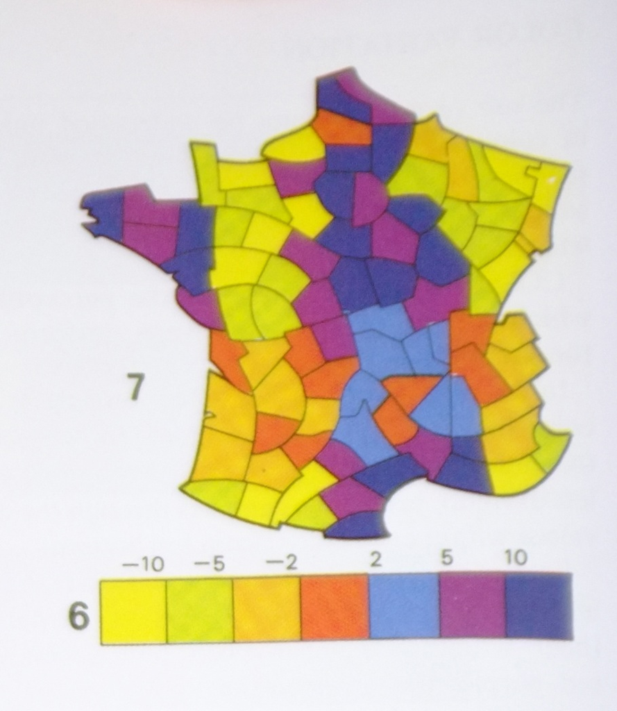

## Another solution uses contours with the original color choice

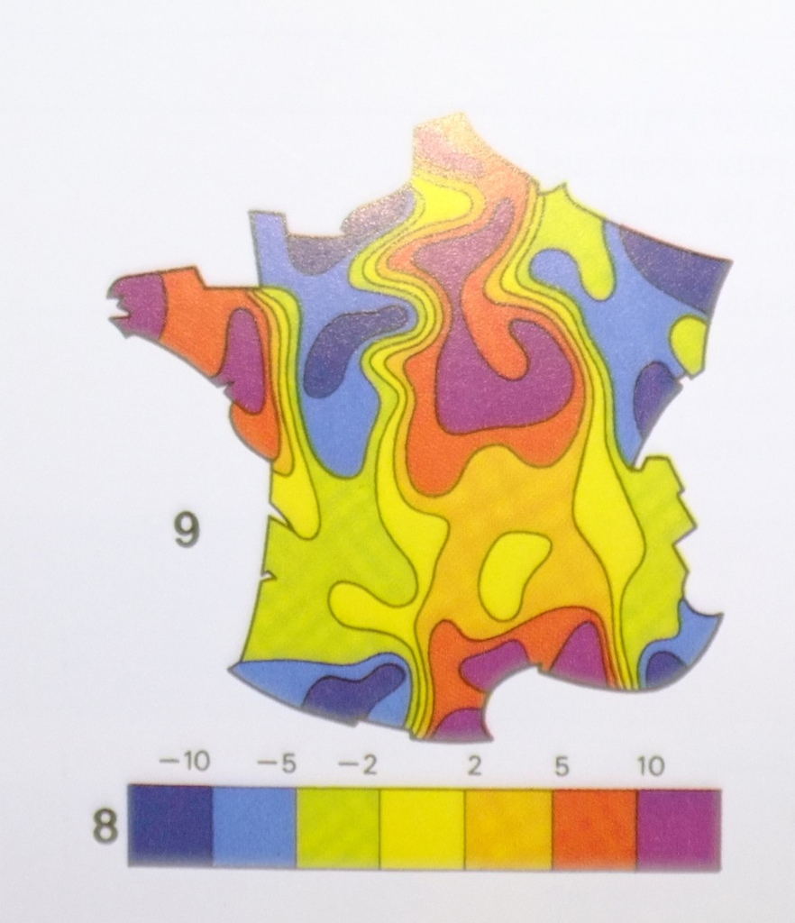

## What do you think of this color choice?

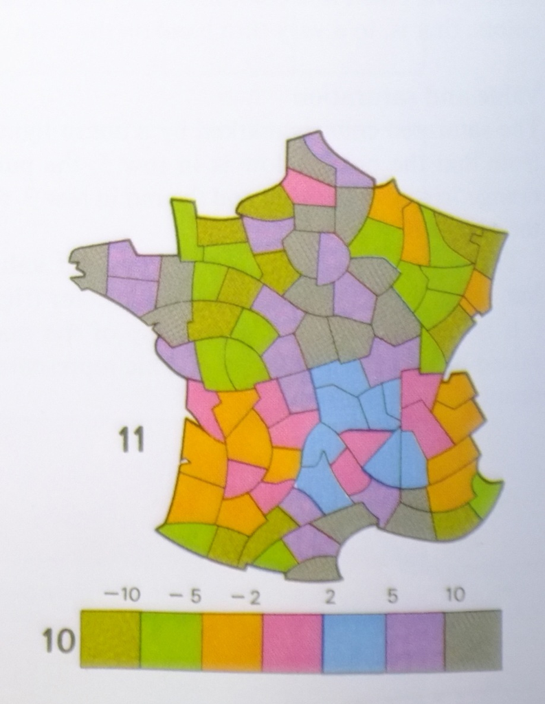

## Pretty and without meaning

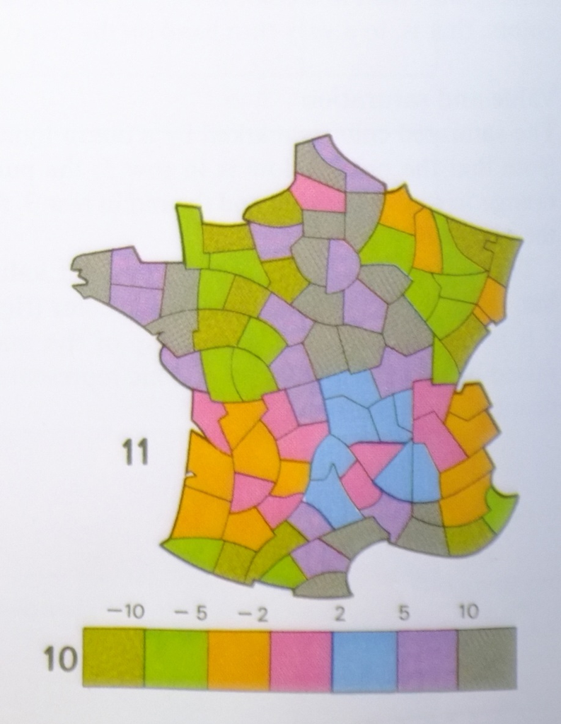

## Exercise: repair a color scale

1. Form a pair.
2. Open this [Google Doc](https://docs.google.com/document/d/1XsJmz15Q1YxyZPu2LnwTFEkuxtbG1VYMBd0kzLSwLFk/edit?usp=sharing).
3. Look again at the spectrum map of France, the one with the rainbow legend. Write one question about the departments it answers quickly and one it fails. (2 min)
4. Sketch three legends for the same seven bins: one varying value alone from light to dark, one cutting the color wheel somewhere other than red, and one using two hues that diverge from the zero bin. (5 min)
5. For each legend, write one question it answers faster than the other two. (3 min)
6. Report your best legend and its question to the class. (4 min)

## Back to the exercise

please think about how you would do it now

## A system for producing graphics

underlying these examples is a process for making graphics in which we analyze the information to determine visual aspects best suited to each kind of information … let’s look at that process

## 1. The invariant

begin to analyze the information by identifying the invariant, the thing that will stay the same across all relationships in the graphic, before considering the components, the things that change

## 1. The invariant

the invariant is the topic of the graphic, for instance sales by county, or labor by county … the invariant gives us the title for the graphic

## Limits of the system

step 1 takes no account of persuasion or provocation because the system strives for the single goal of supporting immediate answers to simple questions about the information

## 2. The components

each component will be represented by a legend on the graph … the components are what varies, such as sales, type of timber, market rank

## 2. The components

each component has three properties to analyze to determine next steps: order, length, and level … three words given precise definitions in the system

## 2. The components

order ranges from components considered as raw values to fractions of components governed by some criteria … for instance workers and workers by county

## 2. The components

length of a component refers to the number of divisions we can identify in it … fewer than four will lead to special constructions while more than a dozen will lead to standard constructions

## 2. The components

level of a component refers to whether the concept is nominal, ordered, or quantitative

## Back to the exercise

please think again about how you would do it now

## Visual information example

Thanks to the two students who worked with me on this study of one student’s solution to the Bertin exercise. This study is more detailed than what I expected you to do in class but serves to illustrate the process.

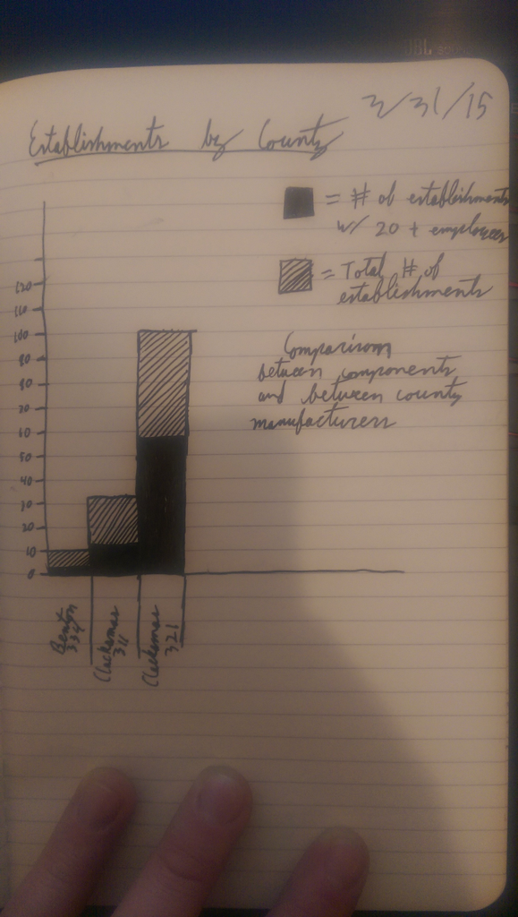

bertin exercise example

## The Invariant

The invariant is represented by the title

## The components

The components are the things that vary in the graphic

## Retinal Variables

The retinal variables are the things that form an image on our retinas

## Bertin’s Theory

It should not be surprising that information design owes so much to a cartographer. This is one of two fields, the other being social network analysis, with the most influence on building information containers today. The remaining sections of this chapter explore Bertin’s theory of information graphics.

## Theories

The word theory is used to mean many things. To obtain a useful definition, it might be helpful to consider what Stephen Hawking says about theory in *A Brief History of Time* on page 7.

*A theory is a good theory if it satisfies two requirements. It must accurately describe a large class of observations on the basis of a model that contains only a few arbitrary elements, and it must make definite predictions about the results of future observations. For example, Aristotle believed Empedocles’s theory that everything was made out of four elements: earth, air, fire, and water. This was simple enough, but did not make any definite predictions. On the other hand, Newton’s theory of gravity was based on an even simpler model, in which bodies attracted each other with a force that was proportional to a quantity called their mass and inversely proportional to the square of the distance between them. Yet it predicts the motions of the sun, the moon, and the planets to a high degree of accuracy.*

## Efficiency

Bertin defines efficiency as a measure of how quickly the process of reading a graphic can be completed and defines the process in some detail under the influence of (then) contemporary philosophy. Let’s read some information graphics now to get an idea of what this might entail.

## Symbols

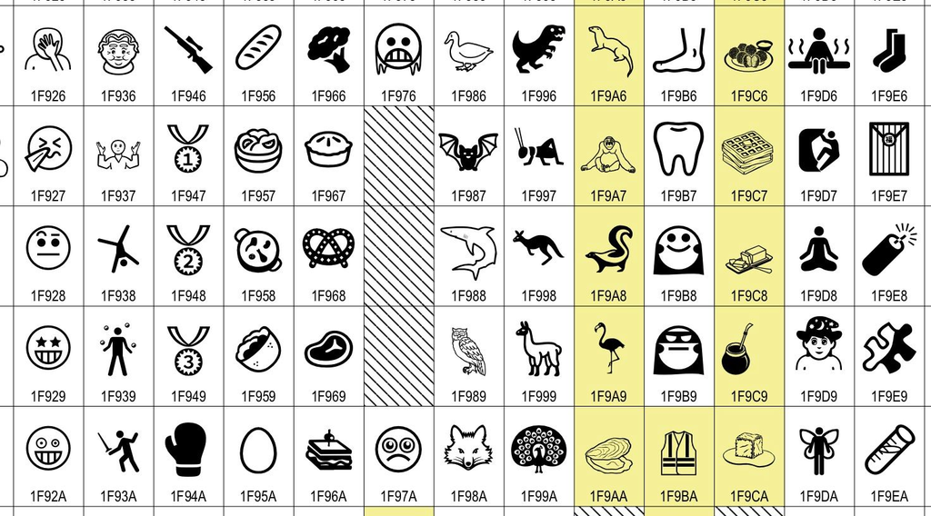

## Diagrams

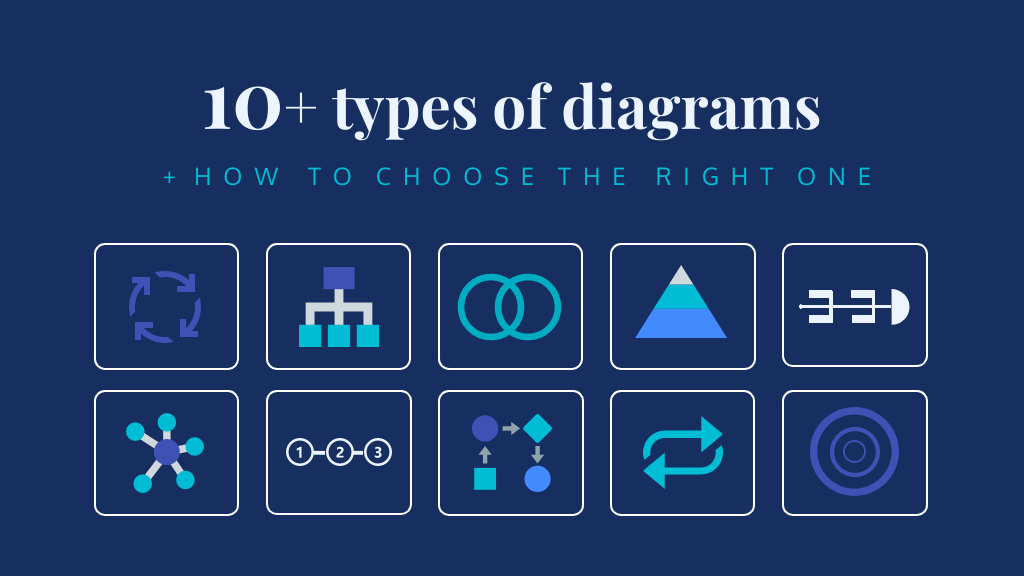

## Networks

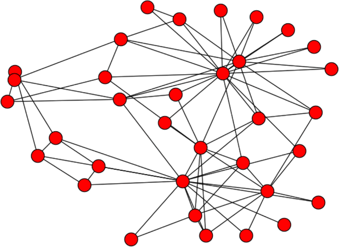